# Jose_Agustin_Ianchina

Dado que el entrenamiento de redes neuronales es una tarea muy costosa, **se recomienda ejecutar el notebooks en [Google Colab](https://colab.research.google.com)**, por supuesto también se puede ejecutar en local.

Al entrar en [Google Colab](https://colab.research.google.com) bastará con hacer click en `upload` y subir este notebook. No olvide luego descargarlo en `File->Download .ipynb`

**El examen deberá ser entregado con las celdas ejecutadas, si alguna celda no está ejecutadas no se contará.**

El examen se divide en tres partes, con la puntuación que se indica a continuación. La puntuación máxima será 10.

- Actividad 1: Redes Densas: 4 pts
  - Correcta normalización: máximo de 0.25 pts
  - Cuestión 1: 1 pt
  - Cuestión 2: 1 pt
  - Cuestión 3: 0.5 pts
  - Cuestión 4: 0.25 pts
  - Cuestión 5: 0.25 pts
  - Cuestión 6: 0.25 pts
  - Cuestión 7: 0.25 pts
  - Cuestión 8: 0.25 pts
- Actividad 2: Redes Convolucionales: 4 pts
  - Cuestión 1: 1 pt
  - Cuestión 2: 1.5 pt
  - Cuestión 3: 0.5 pts
  - Cuestión 4: 0.25 pts
  - Cuestión 5: 0.25 pts
  - Cuestión 6: 0.25 pts
  - Cuestión 7: 0.25 pts
- Actividad 3: Redes Recurrentes: 2 pts
  - Cuestión 1: 0.5 pt
  - Cuestión 2: 0.5 pt
  - Cuestión 3: 0.5 pts
  - Cuestión 4: 0.25 pts
  - Cuestión 5: 0.25 pts

```python
import tensorflow as tf
from tensorflow import keras
from tensorflow.keras import layers
from tensorflow.keras import optimizers
import matplotlib.pyplot as plt
import pandas as pd
import numpy as np
```

# Actividad 1: Redes Densas

Para esta primera actividad vamos a utilizar el [boston housing dataset](https://www.cs.toronto.edu/~delve/data/boston/bostonDetail.html). Con el que trataremos de predecir el precio de una casa con 13 features.

**Puntuación**:

Normalizar las features correctamente (x_train, x_test): 0.1 pts , 0.25 si se normalizan con el [Normalization layer](https://www.tensorflow.org/api_docs/python/tf/keras/layers/experimental/preprocessing/Normalization) de Keras. Ejemplo de uso: [Introduction_to_RNN_Time_Series](https://github.com/ezponda/intro_deep_learning/blob/main/class/RNN/Introduction_to_RNN_Time_Series.ipynb)

```
tf.keras.layers.experimental.preprocessing.Normalization(
    axis=-1, dtype=None, mean=None, variance=None, **kwargs
)
```

- Correcta normalización: máximo de 0.25 pts
- Cuestión 1: 1 pt
- Cuestión 2: 1 pt
- Cuestión 3: 0.5 pts
- Cuestión 4: 0.25 pts
- Cuestión 5: 0.25 pts
- Cuestión 6: 0.25 pts
- Cuestión 7: 0.25 pts
- Cuestión 8: 0.25 pts

```python
(x_train, y_train), (x_test, y_test) = tf.keras.datasets.boston_housing.load_data(
    path='boston_housing.npz',
    test_split=0.2,
)
print('x_train, y_train shapes:', x_train.shape, y_train.shape)
print('x_test, y_test shapes:', x_train.shape, y_train.shape)
print('Some prices: ', y_train[:5])
print(x_train[:1])
```

```
Downloading data from https://storage.googleapis.com/tensorflow/tf-keras-datasets/boston_housing.npz
x_train, y_train shapes: (404, 13) (404,)
x_test, y_test shapes: (404, 13) (404,)
Some prices:  [15.2 42.3 50.  21.1 17.7]
[[  1.23247   0.        8.14      0.        0.538     6.142    91.7
    3.9769    4.      307.       21.      396.9      18.72   ]]
```

```python
## Si quiere, puede normalizar las features
norm = tf.keras.layers.experimental.preprocessing.Normalization(
    axis=-1, dtype=None, mean=None, variance=None
)
norm.adapt(x_train)
```

```python
print('Unnormalized row: ', x_train[:1])
print('Normalized row: ', norm(x_train[:1]))
```

```
Unnormalized row:  [[  1.23247   0.        8.14      0.        0.538     6.142    91.7
    3.9769    4.      307.       21.      396.9      18.72   ]]
Normalized row:  tf.Tensor(
[[-0.27224633 -0.4836155  -0.4357615  -0.25683275 -0.16522722 -0.17644106
   0.8130618   0.11669832 -0.626249   -0.5951698   1.1485013   0.44807735
   0.82522005]], shape=(1, 13), dtype=float32)
```

## Cuestión 1: Cree un modelo secuencial que contenga 4 capas ocultas(hidden layers), con más de 60 neuronas por capa, sin regularización y obtenga los resultados.

Puntuación:

- Obtener el modelo correcto: 0.8 pts
- Compilar el modelo: 0.1pts
- Acertar con la función de pérdida: 0.1 pts

```python
x_train = norm(x_train)
x_test = norm(x_test)
```

```python
model = tf.keras.models.Sequential(
    [
     keras.Input(shape = (13)),
     layers.Dense(64,activation = 'relu'),
     layers.Dense(64,activation = 'relu'),
     layers.Dense(64,activation = 'relu'),
     layers.Dense(64,activation = 'relu'),
     layers.Dense(1,activation = 'relu')
    ]
)
```

```python
# Compilación del modelo
# Código aquí
model.compile(loss = 'mse', optimizer = 'adam', metrics = ['mae','mse'])
```

```python
# No modifique el código
model.fit(x_train,
          y_train,
          epochs=200,
          batch_size=32,
          validation_split=0.2,
          verbose=1)
```

```
<keras.callbacks.History at 0x7f77600a9b90>
```

```python
# No modifique el código
results = model.evaluate(x_test, y_test, verbose=1)
print('Test Loss: {}'.format(results))
```

```
Test Loss: [24.51907730102539, 2.8682096004486084, 24.51907730102539]
```

## Cuestión 2: Utilice el mismo modelo de la cuestión anterior pero añadiendo al menos dos técnicas distinas de regularización.

Ejemplos de regularización: Prevent_Overfitting.ipynb

Puntuación:

- Obtener el modelo con la regularización: 0.8 pts
- Obtener un `test loss` inferior al anterior: 0.2 pts

```python
model = tf.keras.models.Sequential(
    [
     keras.Input(shape = (13)),
     layers.Flatten(),
     layers.Dense(64,activation = 'relu', kernel_regularizer=keras.regularizers.l1()),
     layers.Dense(64,activation = 'relu', kernel_regularizer=keras.regularizers.l2()),
     layers.Dense(64,activation = 'relu', kernel_regularizer=keras.regularizers.l1_l2()),
     layers.Dense(64,activation = 'relu'),
     layers.Dense(1,activation = 'relu')
    ]
)
```

```python
# Compilación del modelo
# Código aquí
model.compile(loss = 'mse', optimizer = 'adam', metrics = ['mae','mse'])
```

```python
batch_size=12 #reducido
```

```python
# No modifique el código
model.fit(x_train,
          y_train,
          epochs=200,
          batch_size=batch_size,
          validation_split=0.2,
          verbose=1)
```

```
<keras.callbacks.History at 0x7f76f64e1b50>
```

```python
# No modifique el código
results = model.evaluate(x_test, y_test, verbose=1)
print('Test Loss: {}'.format(results))
```

```
Test Loss: [17.65748405456543, 2.487467050552368, 14.9887113571167]
```

## Cuestión 3: Utilice el mismo modelo de la cuestión anterior pero añadiendo un callback de early stopping. Obtenga un test loss inferior al del modelo anterior

```python
es_callback = keras.callbacks.EarlyStopping(
    monitor='val_loss',
    patience=10,
    verbose=1)

model = tf.keras.models.Sequential(
    [
     keras.Input(shape = (13)),
     layers.Flatten(),
     layers.Dense(64,activation = 'relu', kernel_regularizer=keras.regularizers.l1()),
     layers.Dense(64,activation = 'relu', kernel_regularizer=keras.regularizers.l2()),
     layers.Dense(64,activation = 'relu', kernel_regularizer=keras.regularizers.l1_l2()),
     layers.Dense(64,activation = 'relu'),
     layers.Dense(1,activation = 'relu')
    ]
)
```

```python
# Compilación del modelo
# Código aquí
model.compile(loss = 'mse', optimizer = 'adam', metrics = ['mae','mse'])
```

```python
## definir el early stopping callback
# Código aquí
model.fit(x_train,
          y_train,
          epochs=200,
          batch_size=32,
          validation_split=0.2,
          verbose=1,
          callbacks=[es_callback]) # Código aquí
```

```
Epoch 75: early stopping
```

```
<keras.callbacks.History at 0x7f76f628ee50>
```

```python
# No modifique el código
results = model.evaluate(x_test, y_test, verbose=1)
print('Test Loss: {}'.format(results))
```

```
Test Loss: [22.59111213684082, 2.7667787075042725, 17.97207260131836]
```

## Cuestión 4: ¿Podría haberse usado otra función de activación de la neurona de salida? En caso afirmativo especifíquela.

```python
model = tf.keras.models.Sequential(
    [
     keras.Input(shape = (13)),
     layers.Flatten(),
     layers.Dense(64,activation = 'relu', kernel_regularizer=keras.regularizers.l1()),
     layers.Dense(64,activation = 'relu', kernel_regularizer=keras.regularizers.l2()),
     layers.Dense(64,activation = 'relu', kernel_regularizer=keras.regularizers.l1_l2()),
     layers.Dense(64,activation = 'relu'),
     layers.Dense(1,activation = 'swish')
    ]
)
model.compile(loss = 'mse', optimizer = 'adam', metrics = ['mae','mse'])
```

```python
model.fit(x_train,
          y_train,
          epochs=200,
          batch_size=32,
          validation_split=0.2,
          verbose=1
          )
```

```
<keras.callbacks.History at 0x7f76f60602d0>
```

```python
results = model.evaluate(x_test, y_test, verbose=1)
print('Test Loss: {}'.format(results))
```

```
Test Loss: [19.128978729248047, 2.6720285415649414, 15.40837574005127]
```

## Cuestión 5: ¿Qué es lo que una neurona calcula?

**a)** Una función de activación seguida de una suma ponderada de las entradas.

**b)** Una suma ponderada de las entradas seguida de una función de activación.

**c)** Una función de pérdida, definida sobre el target.

**d)** Ninguna de las anteriores es correcta

b) Una suma ponderada de las entradas que luego se procesa como entrada de la función de la neurona. (ReLu, sigmoide etc)

## Cuestión 6: ¿Cuál de estas funciones de activación no debería usarse en una capa oculta (hidden layer)?

**a)** `sigmoid`

**b)** `tanh`

**c)** `relu`

**d)** `linear`

d) NO debería usarse lineal, ya que la salida es igual que la entrada.

## Cuestión 7: ¿Cuál de estas técnicas es efectiva para combatir el overfitting en una red con varias capas ocultas? Ponga todas las que lo sean.

**a)** Dropout

**b)** Regularización L2.

**c)** Aumentar el tamaño del test set.

**d)** Aumentar el tamaño del validation set.

**e)** Reducir el número de capas de la red.

**f)** Data augmentation.

a) Dropout  
b) Regularization  
c) Test set. (si se refiere al test set que se deja por fuera del dataset de entrenamiento entonces aumentar su tamaño no ayudaría. Si por el contrario se refiere a hacer mas grande la partición test/train para crear y afinar el modelo entonces si ayuda.)  
d) Misma respuesta que c)  
e) No necesariamente. Si es correcto que reducir la performance del modelo durante el entrenamiento va a ayudar a reducir el overfitting, aunque comprometiendo la performance. Si asumimos en forma general que aumentar capas aumenta la performance entonces reducirlas puede evitar el overfitting.  
f) Aumentar la data de entrada hará que el modelo sea más robusto, y por ende mejoran las probabilidades de que generalice mejor, reduciendo entonces el overfitting.

## Cuestión 8: Supongamos que queremos entrenar una red para un problema de clasificación de imágenes con las siguientes clases: {'perro','gato','persona'}. ¿Cuántas neuronas y que función de activación debería tener la capa de salida? ¿Qué función de pérdida (loss function) debería usarse?

Este es un problema de clasificación multiclase, por ende en la última capa la función de salida a utilizar es Softmax; la cantidad de neuronas tiene que ser 3(una por cada clase).

# Actividad 2: Redes Convolucionales

Vamos a usar el dataset [cifar-10](https://www.cs.toronto.edu/~kriz/cifar.html), que son 60000 imágenes de 32x32 a color con 10 clases diferentes. Para realizar mejor la práctica puede consultar Introduction_to_CNN.ipynb.

**Puntuación**:

- Cuestión 1: 1 pt
- Cuestión 2: 1.5 pt
- Cuestión 3: 0.5 pts
- Cuestión 4: 0.25 pts
- Cuestión 5: 0.25 pts
- Cuestión 6: 0.25 pts
- Cuestión 7: 0.25 pts

Puede normalizar las imágenes al principio o usar la capa Rescaling:

```
tf.keras.layers.experimental.preprocessing.Rescaling(
    scale, offset=0.0, name=None, **kwargs
)
```

```python
(x_train, y_train), (x_test, y_test) = tf.keras.datasets.cifar10.load_data()
y_train = y_train.flatten()
y_test = y_test.flatten()
```

```
Downloading data from https://www.cs.toronto.edu/~kriz/cifar-10-python.tar.gz
```

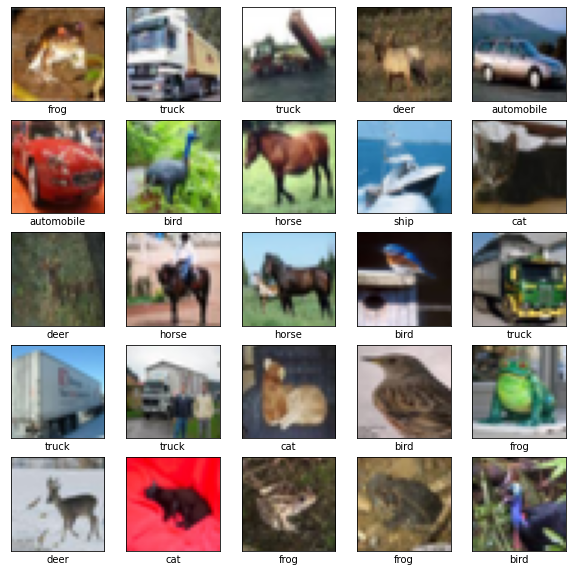

```python
class_names = ['airplane', 'automobile', 'bird', 'cat', 'deer',
               'dog', 'frog', 'horse', 'ship', 'truck']

plt.figure(figsize=(10,10))
for i in range(25):
    plt.subplot(5,5,i+1)
    plt.xticks([])
    plt.yticks([])
    plt.grid(False)
    plt.imshow(x_train[i])
    plt.xlabel(class_names[y_train[i]])
plt.show()
```

```python
print('x_train, y_train shapes:', x_train.shape, y_train.shape)
print('x_test, y_test shapes:', x_test.shape, y_test.shape)
```

```
x_train, y_train shapes: (50000, 32, 32, 3) (50000,)
x_test, y_test shapes: (10000, 32, 32, 3) (10000,)
```

```python
a = (96,96)
b = a + (3,)
b
```

```
(96, 96, 3)
```

## Cuestión 1: Cree una red convolucional con la API funcional con al menos dos capas convolucionales y al menos dos capas de pooling. Utilize sólo [Average Pooling](https://www.tensorflow.org/api_docs/python/tf/keras/layers/AveragePooling2D) y no añada ninguna regularización.

```python
inputs = tf.keras.Input(shape=(32,32,3), name='input')
# reescaling
rescaling = layers.Rescaling(1./255)(inputs)

# Convolution + pooling layers
conv_1 = layers.Conv2D(12, 3, padding='valid', activation='relu',
                       name='conv_1')(rescaling)
pool_1 = layers.AveragePooling2D(pool_size=(2, 2), name='pool_1')(conv_1)

conv_2 = layers.Conv2D(12, 3, padding='valid', activation='relu',
                       name='conv_2')(pool_1)
pool_2 = layers.AveragePooling2D(pool_size=(2, 2), name='pool_2')(conv_2)

# Flattening
flat = layers.Flatten(name='flatten')(pool_2)

# Fully-connected
dense = layers.Dense(64, activation='relu', name='dense')(flat)
outputs = layers.Dense(10, activation='softmax', name='output')(dense)

model = keras.Model(inputs=inputs, outputs=outputs)
```

```python
model.compile(optimizer='adam',
              loss=tf.keras.losses.SparseCategoricalCrossentropy(),
              metrics=['accuracy'])
```

```python
history = model.fit(x_train, y_train, epochs=25, batch_size=64,
                    validation_split=0.15)
```

```python
results = model.evaluate(x_test, y_test, verbose=0, batch_size=1000)
print('Test Loss: {}'.format(results[0]))
print('Test Accuracy: {}'.format(results[1]))
```

```
Test Loss: 1.0885984897613525
Test Accuracy: 0.632099986076355
```

## Cuestión 2: Cree un modelo con la API funcional con un máximo de 2 capas convolucionales y un máximo de 2 capas de pooling. Utilize [Max Pooling](https://www.tensorflow.org/api_docs/python/tf/keras/layers/MaxPool2D) o [Average Pooling](https://www.tensorflow.org/api_docs/python/tf/keras/layers/AveragePooling2D) y añada la regularización que quiera. Debe obtener un `Test accuracy > 0.68`

```python
inputs = tf.keras.Input(shape=(32,32,3), name='input')
# reescaling
rescaling = layers.Rescaling(1./255)(inputs)

# Convolution + pooling layers
conv_1 = layers.Conv2D(32, 4, padding='same', activation='swish',
                       name='conv_1')(rescaling)
pool_1 = layers.MaxPooling2D(pool_size=(1, 2), name='pool_1')(conv_1)
dropout_1 = layers.Dropout(0.5)(pool_1)

conv_2 = layers.Conv2D(16, 3, padding='same', activation='swish',
                       name='conv_2')(dropout_1)
pool_2 = layers.MaxPooling2D(pool_size=(2, 1), name='pool_2')(conv_2)
dropout_2 = layers.Dropout(0.5)(pool_2)

# Flattening
flat = layers.Flatten(name='flatten')(dropout_2)

# Fully-connected
dense = layers.Dense(64, activation='swish', name='dense')(flat)
outputs = layers.Dense(10, activation='softmax', name='output')(dense)

model = keras.Model(inputs=inputs, outputs=outputs)
```

```python
model.compile(optimizer='adam',
              loss=tf.keras.losses.SparseCategoricalCrossentropy(),
              metrics=['accuracy'])
```

```python
es_callback = keras.callbacks.EarlyStopping(
    monitor='val_accuracy',
    patience=8,
    verbose=1)
history = model.fit(x_train, y_train, epochs=50, batch_size=13,
                    validation_split=0.4, callbacks=[es_callback])
```

```
Epoch 34: early stopping
```

```python
results = model.evaluate(x_test, y_test, verbose=0, batch_size=1000)
print('Test Loss: {}'.format(results[0]))
print('Test Accuracy: {}'.format(results[1]))
```

```
Test Loss: 1.1309692859649658
Test Accuracy: 0.6506999731063843
```

## Cuestión 3: Añada data augmentation al principio del modelo

```python
keras.__version__
```

```
'2.8.0'
```

```python
data_augmentation = keras.Sequential(
  [
    layers.RandomFlip("horizontal_and_vertical"),
    layers.RandomRotation(0.25),
    layers.RandomZoom(0.25),
    layers.RandomContrast(0.1),
  ]
)
```

```python
inputs = tf.keras.Input(shape=(32,32,3), name='input')

#data augmentation
data_aug = data_augmentation(inputs)

# reescaling
rescaling = layers.Rescaling(1./255)(data_aug)

# Convolution + pooling layers
conv_1 = layers.Conv2D(32, 4, padding='same', activation='swish',
                       name='conv_1')(rescaling)
pool_1 = layers.MaxPooling2D(pool_size=(2, 2), name='pool_1')(conv_1)
#dropout_1 = layers.Dropout(0.4)(pool_1)

conv_2 = layers.Conv2D(24, 3, padding='same', activation='swish',
                       name='conv_2')(pool_1)
pool_2 = layers.MaxPooling2D(pool_size=(2, 2), name='pool_2')(conv_2)
#dropout_2 = layers.Dropout(0.4)(pool_2)

# Flattening
flat = layers.Flatten(name='flatten')(pool_2)

# Fully-connected
dense = layers.Dense(64, activation='swish', name='dense')(flat)
outputs = layers.Dense(10, activation='softmax', name='output')(dense)

model = keras.Model(inputs=inputs, outputs=outputs)
```

```python
model.compile(optimizer='adam',
              loss=tf.keras.losses.SparseCategoricalCrossentropy(),
              metrics=['accuracy'])
```

```python
es_callback = keras.callbacks.EarlyStopping(
    monitor='val_accuracy',
    patience=8,
    verbose=1)
history = model.fit(x_train, y_train, epochs=200, batch_size=64,
                    validation_split=0.15, callbacks=[es_callback])
```

```
Epoch 25: early stopping
```

```python
results = model.evaluate(x_test, y_test, verbose=0, batch_size=1000)
print('Test Loss: {}'.format(results[0]))
print('Test Accuracy: {}'.format(results[1]))
```

```
Test Loss: 1.38225519657135
Test Accuracy: 0.5145999789237976
```

## Cuestión 4: Cree el mismo modelo de manera secuencial. No es necesario compilar ni entrenar el modelo

```python
model_seq = tf.keras.models.Sequential()
# Código aquí
model_seq.add(layers.Rescaling(1./255))

model_seq.add(layers.Conv2D(32,4,padding='same',activation='swish',name='conv_1'))
model_seq.add(layers.MaxPooling2D(pool_size=(2,2),name='pool_1'))

model_seq.add(layers.Conv2D(32,4,padding='same',activation='swish',name='conv_2'))
model_seq.add(layers.MaxPooling2D(pool_size=(2,2),name='pool_2'))

model_seq.add(layers.Flatten(name='flatten'))

model_seq.add(layers.Dense(64,activation='swish',name='dense'))
model_seq.add(layers.Dense(10,activation='softmax',name='output'))
```

## Cuestión 5: Si tenenemos una una imagen de entrada de 300 x 300 a color (RGB) y queremos usar una red densa. Si la primera capa oculta tiene 100 neuronas, ¿Cuántos parámetros tendrá esa capa (sin incluir el bias) ?

```python
300*300*3*100
```

```
27000000
```

## Cuestión 6 Ponga las verdaderas ventajas de las redes convolucionales respecto a las densas

**a)** Reducen el número total de parámetros, reduciendo así el overfitting.

**b)** Permiten utilizar una misma 'función' en varias localizaciones de la imagen de entrada, en lugar de aprender una función diferente para cada pixel.

**c)** Permiten el uso del transfer learning.

**d)** Generalmente son menos profundas, lo que facilita su entrenamiento.

Todas son correctas

## Cuestión 7: Para el procesamiento de series temporales las redes convolucionales no son efectivas, habrá que usar redes recurrentes.

- **Verdadero**
- **Falso**

Verdero, se requiere modelar data ordenada

# Actividad 3: Redes Recurrentes

- Cuestión 1: 0.5 pt
- Cuestión 2: 0.5 pt
- Cuestión 3: 0.5 pts
- Cuestión 4: 0.25 pts
- Cuestión 5: 0.25 pts

Vamos a usar un dataset de las temperaturas mínimas diarias en Melbourne. La tarea será la de predecir la temperatura mínima en dos días. Puedes usar técnicas de series temporales vistas en otras asignaturas, pero no es necesario.

```python
dataset_url = 'https://raw.githubusercontent.com/jbrownlee/Datasets/master/daily-min-temperatures.csv'
data_dir = tf.keras.utils.get_file('daily-min-temperatures.csv', origin=dataset_url)
```

```
Downloading data from https://raw.githubusercontent.com/jbrownlee/Datasets/master/daily-min-temperatures.csv
```

```python
df = pd.read_csv(data_dir, parse_dates=['Date'])
df.head()
```

|  | Date | Temp |
| --- | --- | --- |
| 0 | 1981-01-01 | 20.7 |
| 1 | 1981-01-02 | 17.9 |
| 2 | 1981-01-03 | 18.8 |
| 3 | 1981-01-04 | 14.6 |
| 4 | 1981-01-05 | 15.8 |

```python
temperatures = df['Temp'].values
print('number of samples:', len(temperatures))
train_data = temperatures[:3000]
test_data = temperatures[3000:]
print('number of train samples:', len(train_data))
print('number of test samples:', len(test_data))
print('firsts trainn samples:', train_data[:10])
```

```
number of samples: 3650
number of train samples: 3000
number of test samples: 650
firsts trainn samples: [20.7 17.9 18.8 14.6 15.8 15.8 15.8 17.4 21.8 20. ]
```

```python
mu = train_data.mean()
sigma = train_data.std()
print('mu, sigma: ', mu, sigma)

train_data = (train_data - mu) / sigma
test_data = (test_data - mu) / sigma
```

```
mu, sigma:  11.241366666666664 4.11104027372905
```

## Cuestión 1: Convierta `train_data` y `test_data` en ventanas de tamaño 5, para predecir el valor en 2 días

En la nomenclatura de Introduction_to_RNN_Time_Series.ipynb

```
past, future = (5, 2)
```

Para las primeras 10 muestras de train_data `[20.7, 17.9, 18.8, 14.6, 15.8, 15.8, 15.8, 17.4, 21.8, 20. ]` el resultado debería ser:

```
x[0] : [20.7, 17.9, 18.8, 14.6, 15.8] , y[0]: 15.8
x[1] : [17.9, 18.8, 14.6, 15.8, 15.8] , y[1]: 17.4
x[2] : [18.8, 14.6, 15.8, 15.8, 15.8] , y[2]: 21.8
x[3] : [14.6, 15.8, 15.8, 15.8, 17.4] , y[3]: 20.
```

```python
# windowing function
def convert2matrix(data_arr, past, future, shuffle=False):
    X, Y = [], []
    size = len(data_arr)
    for i in range(size - future - past + 1):
        d = i + past
        y_ind = i + past + future - 1
        X.append(data_arr[i:d])
        Y.append(data_arr[y_ind])
    #if shuffle:
    #    c = list(zip(X, Y))
    #    random.shuffle(c)
    #    X, Y = zip(*c)
    return np.array(X), np.array(Y)
```

```python
past, future = (5, 2)
X_train, y_train = convert2matrix(train_data, past, future)
X_test, y_test = convert2matrix(test_data, past, future)
```

```python
len(X_train)
```

```
2994
```

```python
len(y_train)
```

```
2994
```

## Cuestión 2: Cree un modelo recurrente de dos capas GRU para predecir con las ventanas de la cuestión anterior.

```python
inputs = keras.layers.Input(shape=(past, 1))
gru_1 = keras.layers.GRU(64, return_sequences=True, name = 'gru_1')(inputs)
gru_2 = keras.layers.GRU(64, return_sequences=False, name = 'gru_2')(gru_1)
outputs = keras.layers.Dense(2)(gru_2)
model = keras.Model(inputs=inputs, outputs=outputs)
model.compile(optimizer = keras.optimizers.Adam(), loss = 'mse')
model.summary()
```

```
Model: "model_3"
_________________________________________________________________
 Layer (type)                Output Shape              Param #
=================================================================
 input_5 (InputLayer)        [(None, 5, 1)]            0

 gru_1 (GRU)                 (None, 5, 64)             12864

 gru_2 (GRU)                 (None, 64)                24960

 dense_20 (Dense)            (None, 2)                 130

=================================================================
Total params: 37,954
Trainable params: 37,954
Non-trainable params: 0
_________________________________________________________________
```

```python
es_callback = keras.callbacks.EarlyStopping(
    monitor="val_loss", min_delta=0, patience=10)

history = model.fit(
    X_train, y_train,
    epochs=200,
    validation_split=0.2, shuffle=True, batch_size = 64, callbacks=[es_callback]
)
```

```python
results = model.evaluate(X_test, y_test, verbose=1)
print('Test Loss: {}'.format(results))
```

```
Test Loss: 0.4152001738548279
```

## Cuestión 3: Añada más features a la series temporal, por ejemplo `portion_year`. Cree un modelo que mejore al anterior.

```python
## Puede añadir más features
df['portion_year'] = df['Date'].dt.dayofyear / 365.0
df_multi = df[['Temp', 'portion_year']].copy()

## train - test split
train_data = df_multi.iloc[:3000].copy()
test_data = df_multi.loc[3000:, :].copy()
```

```python
train_data.head()
```

|  | Temp | portion_year |
| --- | --- | --- |
| 0 | 20.7 | 0.002740 |
| 1 | 17.9 | 0.005479 |
| 2 | 18.8 | 0.008219 |
| 3 | 14.6 | 0.010959 |
| 4 | 15.8 | 0.013699 |

```python
features = df_multi.columns
mu_dict = {}
sigma_dict = {}
for c in features:
    mu = train_data[c].mean()
    sigma = train_data[c].std()
    mu_dict[c] = mu
    sigma_dict[c] = sigma
    print('feature: {0} , mu,sigma'.format(c), mu, sigma)
print(mu_dict, sigma_dict)
```

```
feature: Temp , mu,sigma 11.241366666666664 4.111725618448945
feature: portion_year , mu,sigma 0.49095890410958903 0.2918934805568379
{'Temp': 11.241366666666664, 'portion_year': 0.49095890410958903} {'Temp': 4.111725618448945, 'portion_year': 0.2918934805568379}
```

```python
for c in features:
    mu = mu_dict[c]
    sigma = sigma_dict[c]
    train_data.loc[:, c] = (train_data[c].values - mu) / sigma
    test_data.loc[:, c] = (test_data[c].values - mu) / sigma
train_data.describe()
```

|  | Temp | portion_year |
| --- | --- | --- |
| count | 3.000000e+03 | 3.000000e+03 |
| mean | 5.826450e-16 | 1.184238e-17 |
| std | 1.000000e+00 | 1.000000e+00 |
| min | -2.733978e+00 | -1.672594e+00 |
| 25% | -7.153606e-01 | -8.935517e-01 |
| 50% | -3.438135e-02 | -1.126326e-02 |
| 75% | 6.709186e-01 | 8.710252e-01 |
| max | 3.662363e+00 | 1.743928e+00 |

```python
def convert2matrix_multi(df, past, future, target, shuffle=False):
    X, Y = [], []
    size = len(df)
    for i in range(size - future - past + 1):
        d = i + past
        y_ind = i + past + future - 1
        X.append(df.iloc[i:d, :].values)
        Y.append(df.iloc[y_ind][target])
    #if shuffle:
    #    c = list(zip(X, Y))
    #    random.shuffle(c)
    #    X, Y = zip(*c)
    return np.array(X), np.array(Y)
```

```python
## Create windows
past, future = (5, 2)
X_train, y_train = convert2matrix_multi(train_data, past, future, target = 'Temp')
X_test, y_test = convert2matrix_multi(test_data, past, future, target = 'Temp')
```

```python
inputs = keras.layers.Input(shape=(past, 2))
gru_1 = keras.layers.GRU(64, return_sequences=True, name = 'gru_1', recurrent_dropout=0.2)(inputs)
gru_2 = keras.layers.GRU(64, return_sequences=False, name = 'gru_2', recurrent_dropout=0.2)(gru_1)
outputs = keras.layers.Dense(2)(gru_2)
model = keras.Model(inputs=inputs, outputs=outputs)
model.compile(optimizer = keras.optimizers.Adam(), loss = 'mse')
model.summary()
```

```
WARNING:tensorflow:Layer gru_1 will not use cuDNN kernels since it doesn't meet the criteria. It will use a generic GPU kernel as fallback when running on GPU.
WARNING:tensorflow:Layer gru_2 will not use cuDNN kernels since it doesn't meet the criteria. It will use a generic GPU kernel as fallback when running on GPU.
Model: "model_5"
_________________________________________________________________
 Layer (type)                Output Shape              Param #
=================================================================
 input_7 (InputLayer)        [(None, 5, 2)]            0

 gru_1 (GRU)                 (None, 5, 64)             13056

 gru_2 (GRU)                 (None, 64)                24960

 dense_22 (Dense)            (None, 2)                 130

=================================================================
Total params: 38,146
Trainable params: 38,146
Non-trainable params: 0
_________________________________________________________________
```

```python
es_callback = keras.callbacks.EarlyStopping(
    monitor="val_loss", min_delta=0, patience=10)

history = model.fit(
    X_train, y_train,
    epochs=200,
    validation_split=0.2, shuffle=True, batch_size = 64, callbacks=[es_callback]
)
```

```python
results = model.evaluate(X_test, y_test, verbose=1)
print('Test Loss: {}'.format(results))
```

```
Test Loss: 0.3649601638317108
```

## Cuestión 4: ¿En cuáles de estas aplicaciones se usaría un arquitectura 'many-to-one'?

**a)** Clasificación de sentimiento en textos

**b)** Verificación de voz para iniciar el ordenador.

**c)** Generación de música.

**d)** Un clasificador que clasifique piezas de música según su autor.

a) Clasificación de sentimiento en textos usaría many-to-one.

## Cuestión 5: ¿Qué ventajas aporta el uso de word embeddings?

**a)** Permiten reducir la dimensión de entrada respecto al one-hot encoding.

**b)** Permiten descubrir la similaridad entre palabras de manera más intuitiva que con one-hot encoding.

**c)** Son una manera de realizar transfer learning en nlp.

**d)** Permiten visualizar las relaciones entre palabras con métodos de reducción de dimensioones como el PCA.

a) Verdadero  
b) Verdadero